# Proyecto Final R

Alicia Díaz Castillo

## EXPRESIONES REGULARES

En esta sección seleccionaremos dos páginas web explicando expresiones regulares en R.

### Rpubs

En esta página web, http://rpubs.com/ydmarinb/429756 me parece que viene muy bien explicado y estructurado. Al empezar da una breve explicación sobre que son las expresiones regulares. Además, está estructurado de una manera para que el lector lo comprenda al momento, y si quiere algo en especial, solo tiene que pinchar en el índice. En cada parte viene con un ejemplo para enseñar como se usaría cada expresión. Y además está creado con Rmarkdown.

### Diego Calvo

La segunda es http://www.diegocalvo.es/expresiones-regulares-en-r/, comparado con la anterior me parece que la estructura no es tan buena. En mi opinión, le falta una pequeña explicación para los que no saben que nada sobre expresiones regulares, y se centra menos en la explicación de cada función.

## RMARKDOWN

En esta sección vamos a comparar dos páginas web en las que expliquen Rmardown.

### Bookdown

En la página web https://bookdown.org/gboccardo/manual-ED-UCH/introduccion-al-uso-de-rmarkdown-para-la-compilacion-de-resultados-de-rstudio-en-diferentes-formatos.html#tabla-de-estadisticos-univariados. Lo contenidos estan muy bien explicados, en profundidad. Y explica como crear todo tipo de elementos como tablas o listas. La estructura de como viene organizado el contenido esta muy bien ya que explica del contenido más simple al más complejo.

### Rpubs

Desde mi punto de vista, https://rpubs.com/JohanMarin/Rmarkdown es más visual que el anterior. En contenidos explican más o menos lo mismo, sin embargo, este explica como incluir imágenes, código in-line, strings externos. Aunque la estructura no es la mejor, ya que explica como crear tablas o listas, antes de explicar lo más principal. Un punto a su favor es que esta hecho en Rmarkdown.

## ESTUDIO DE LOS VOTOS DEL PAÍS VASCO EN EL 2016.

Los datos los he obtenido de la página web http://opendata.esri.es/datasets/pais-vasco-elecciones-auton%C3%B3micas-2016/geoservice, usando su API, con formato geojson. Primeramente lo transformamos a formato tabla, y la iremos mejorando estéticamente, renombrando las columnas, eliminando columnas que no daban información y transfromando el formato de la fecha en fecha.

| OBJECTID | codine | AMBITO | Censo | Votantes | Nulos | Válidos | Blancos | Votos_Cand_ | Abstenciones | EAJ_PNV | PP | PH | EK_PCPE | PSE_EE_PSOE | PACMA_ATTKA | PFYV | C´S | EB_AZ | O_E_ | EH_BILDU | VOX | GANEMOS | LN | PODEMOS_AHAL_DUGU_IU | RECORTES_CERO_GV | Shape__Area | Shape__Length | Fecha |
| --- | --- | --- | --- | --- | --- | --- | --- | --- | --- | --- | --- | --- | --- | --- | --- | --- | --- | --- | --- | --- | --- | --- | --- | --- | --- | --- | --- | --- |
| 1 | 01001 | ALEGRÍA-DULANTZI | 1986 | 1177 | 8 | 1169 | 9 | 1160 | 809 | 403 | 120 | 0 | 0 | 143 | 15 | 0 | 29 | 2 | 0 | 241 | 1 | 6 | 0 | 195 | 5 | 37060213 | 47644.75 | 2016-09-25 03:00:00 |
| 2 | 01002 | AMURRIO | 8120 | 5574 | 44 | 5530 | 33 | 5497 | 2546 | 2298 | 356 | 0 | 0 | 421 | 31 | 0 | 66 | 15 | 2 | 1367 | 35 | 22 | 0 | 865 | 19 | 180265685 | 88515.99 | 2016-09-25 03:00:00 |
| 3 | 01003 | ARAMAIO | 1191 | 839 | 2 | 837 | 4 | 833 | 352 | 289 | 5 | 0 | 0 | 16 | 1 | 0 | 0 | 1 | 0 | 434 | 4 | 6 | 0 | 77 | 0 | 137228238 | 56928.33 | 2016-09-25 03:00:00 |
| 4 | 01004 | ARTZINIEGA | 1408 | 947 | 11 | 936 | 6 | 930 | 461 | 389 | 99 | 0 | 0 | 57 | 9 | 0 | 11 | 1 | 1 | 234 | 4 | 6 | 0 | 117 | 2 | 51284789 | 31193.72 | 2016-09-25 03:00:00 |
| 5 | 01006 | ARMIÑÓN | 174 | 110 | 3 | 107 | 0 | 107 | 64 | 18 | 30 | 0 | 0 | 12 | 2 | 0 | 5 | 0 | 0 | 12 | 3 | 2 | 0 | 22 | 1 | 23925269 | 33398.35 | 2016-09-25 03:00:00 |
| 6 | 01008 | ARRATZUA-UBARRUNDIA | 778 | 480 | 3 | 477 | 3 | 474 | 298 | 172 | 82 | 0 | 0 | 33 | 3 | 0 | 10 | 0 | 0 | 114 | 3 | 0 | 0 | 51 | 6 | 107195193 | 90446.33 | 2016-09-25 03:00:00 |
| 7 | 01009 | ASPARRENA | 1268 | 803 | 3 | 800 | 5 | 795 | 465 | 297 | 42 | 0 | 0 | 45 | 4 | 0 | 3 | 2 | 0 | 291 | 0 | 1 | 0 | 107 | 3 | 121700060 | 72826.48 | 2016-09-25 03:00:00 |
| 8 | 01010 | AYALA/AIARA | 2271 | 1593 | 14 | 1579 | 4 | 1575 | 678 | 749 | 104 | 0 | 0 | 65 | 9 | 0 | 17 | 3 | 3 | 405 | 7 | 8 | 0 | 202 | 3 | 263915939 | 87124.65 | 2016-09-25 03:00:00 |
| 9 | 01011 | BAÑOS DE EBRO/MAÑUETA | 230 | 148 | 4 | 144 | 2 | 142 | 82 | 55 | 56 | 0 | 0 | 15 | 0 | 0 | 4 | 0 | 0 | 4 | 0 | 3 | 0 | 5 | 0 | 17262182 | 25118.12 | 2016-09-25 03:00:00 |
| 10 | 01013 | BARRUNDIA | 715 | 437 | 0 | 437 | 0 | 437 | 278 | 138 | 42 | 0 | 0 | 21 | 1 | 0 | 3 | 0 | 0 | 166 | 3 | 0 | 0 | 61 | 2 | 181660134 | 77662.49 | 2016-09-25 03:00:00 |

### Relación entre el censo y el número de votantes.

En esta sección relacionaremos el número de población de cada distrito con el número de votantes. Como se puede observar en la tabla de la derecha las ciudades más pobladas coinciden con las capitales de Álava, Guipúzcoa y Vizcaya.

|  | AMBITO | Censo |
| --- | --- | --- |
| 159 | BILBAO | 273513 |
| 45 | VITORIA-GASTEIZ | 186647 |
| 120 | DONOSTIA/SAN SEBASTIÁN | 147061 |
| 152 | BARAKALDO | 79614 |
| 183 | GETXO | 62703 |
| 96 | IRUN | 46709 |

Para poder realizar el estudio más fácilmente creamos nuevas columnas que contienen el *porcentaje de participación* de cada distrito y el *ranking del censo*, en orden descendente, es decir el número uno será el más poblado.

[interactive chart not shown]

A continuación, estudiaremos el **porcentaje de votación** y el tipo de **población** de cada provincia, para ello identificamos cada provincia con el código postal de cada distrito creando una nueva columna llamada *Provincia*.

En el siguiente diagrama de violin comparamos el **porcentaje de población** por **provincias**. Se puede apreciar que la media del porcentaje de votos es más alto en Vizcaya, además de estar más equilibrado. Guipúzcoa y Álava estan bastante igualadas. Sin embargo, en Álava es donde se registran los menores porcentajes y en Guipúzcoa los mayores. Además, Guipúzcoa destaca porque en la mayoría de distritos el porcentaje se encuentra alrededor de un 63%.

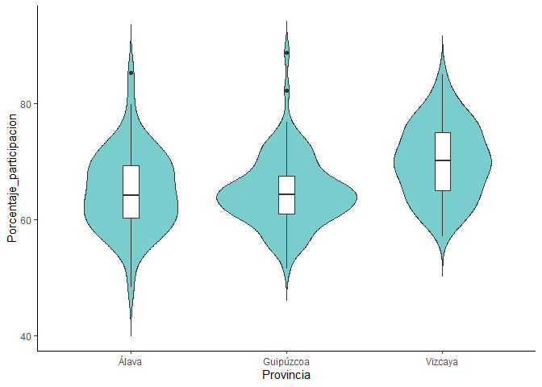

En el diagrama de violin del **ranking del censo**, hay una gran diferencia del tipo de población de Álava con los otros dos. En Álava lo que más hay son pueblos pequeños o medianos, entre el ranking 150 y 245, A partir de 150 va disminuyendo el número, y ciudades grandes, hay muy pocas. Entre Vizcaya y guipúzcoa no hay gran diferencia, lo único que en Vizcaya no se encuentran casi pueblos pequeños, y Guipúzcoa tiene mucha variendad entre tipo de población teniendo casi el mismo número de pueblos pequeños que ciudades grandes.

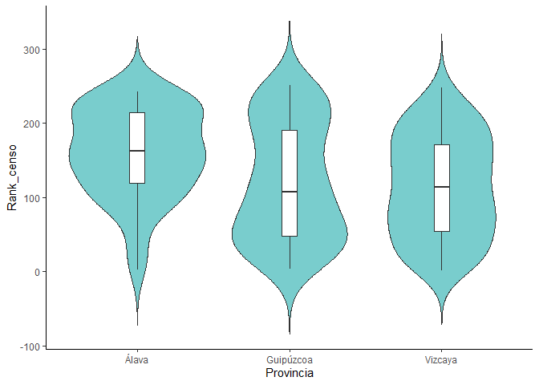

Lo curioso es que el pueblo con menos habitantes del País Vasco pertenece a Guipúzcoa y es el que tiene mayor porcentaje de votos de todos los distritos.

### Partidos políticos.

En esta sección se estudiará cuales son **los partidos políticos más votados en cada provincia**. Para ello se creará el siguiente diagrama de barras, en el cual en cada provincia se contabiliza el porcentaje de votos respecto a la población de cada una. Se puede ver que el partido ganador en las tres provincias es el PNV(Partido Nacionalista Vasco), seguido por BILDU en Vizcaya Y Guipúzcua. En Álava no hay una gran diferencia entre el PP y BILDU, ganando el PP. Además hay partidos que no consiguen ni un voto, como Vox en Vizcaya.

[interactive chart not shown]